# brennas_OriginalHomeworkCode_04

brennastallings

10/19/2019

This is for [Homework 4](https://fuzzyatelin.github.io/bioanth-stats/homework-04.html)

#FA: Overall your code looks great!, I only included some comments for the legend to show up (line 302-311) - Althought I am not sure if this is correct I couldnt get the legend to work :( >Question 1

#Write a simple R function, Z.prop.test(), that can perform one- or two-sample Z-tests for proportion data, using the following guidelines: ~There is a sample large function in [Module 11](https://fuzzyatelin.github.io/bioanth-stats/module-11/module-11.html)

Your function should take the following arguments: p1 and n1 (no default) representing the estimated proportion and sample size (i.e., based on your sample data); p2 and n2 (both defaulting to NULL) that contain a second sample’s proportion and sample size data in the event of a two-sample test; p0 (no default) as the expected value for the population proportion; and alternative (default “two.sided”) and conf.level (default 0.95), to be used in the same way as in the function t.test(). This sets up the beginning, skeleton, function

```r
z.prop.test <- function(p1, n1, p2= NULL, n2= NULL, p0, alternative="two.tailed", conf.level=0.95){

                }
```

I wrote this code piece by piece, so these are so I can test individual equations

```r
p1 = 0.8
p2 = 0.3
p0 = 0.4
n1 = 25
n2 = 5
conf.level = 0.95
```

When conducting a two-sample test, it should be p1 that is tested as being smaller or larger than p2 when alternative=“less” or alternative=“greater”, the same as in the use of x and y in the function t.test().

The function should perform a one-sample Z-test using p1, n1, and p0 if either p2 or n2 (or both) is NULL.

The function should contain a check for the rules of thumb we have talked about (n∗p>5 and n∗(1−p)>5) to ensure the validity of assuming the normal distribution in both the one- and two-sample settings. If this is violated, the function should still complete but it should also print an appropriate warning message. #this should be if statements

```
## [1] "Caution, n*p in less than 5, violating normality assumption"
```

```
## [1] "Caution, n*(1-p) in less than 5, violating normality assumption"
```

The function should return a list containing the members Z (the test statistic), P (the appropriate p value), and CI (the two-sided CI with respect to “conf.level” around p1 in the case of a one-sample test and around p2-p1 in the case of a two-sample test). For all test alternatives (“two.sided”, “greater”, “less”), calculate symmetric CIs based on quantiles of the normal distribution rather than worrying about calculating single-limit confidence bounds.

#this can be put after all if statemnets

What i want for final function to be arranged:  
1.if alt= less, calculate values  
2.if alt= greater, calculate values  
3.if alt= two.tailed, calculate values  
4.if p2 or n2 is null, calulate values  
5.if there are errors, print warning  
6.print values

This is for my final function. I am trying to add it one piece at a time

```r
z.prop.test <- function(p1, n1, p0, p2= NULL, n2= NULL, alternative="two.tailed", conf.level=0.95){
   if (alternative == "two.tailed")
  {
    z<- (p1-p0)/sqrt((p0*(1-p0))/n1)
    p<- pnorm(z, lower.tail = T)
    lower <- (p1-qnorm(conf.level) * sqrt(p1*(1-p1))/n1)
    upper <- (p1+qnorm(conf.level) * sqrt(p1*(1-p1))/n1)
    ci <- c(lower, upper)
   }
#this is for if n2 or p2 is null
  if (is.null(n2)|is.null(p2))
  {
    z<- (p1-p0)/sqrt((p0*(1-p0))/n1)
    p<- pnorm(z, lower.tail = T)
    lower <- (p1-qnorm(conf.level) * sqrt(p1*(1-p1))/n1)
    upper <- (p1+qnorm(conf.level) * sqrt(p1*(1-p1))/n1)
    ci <- c(lower, upper)
  }
#this is for if p1 is less than p2
    if (alternative == "less")
  {
    pstar<- (sum(p1*n1)+sum(p2*n2))/(n1+n2)
    #sum(p1*n1) gives the number of sucesses, which is x1
    #n1 is the number of observations
    z<- (p2 - p1)/sqrt((pstar * (1-pstar)) * (1/length(n1) + 1/length(n2)))
    p<- 1-pnorm(z, lower.tail = T) + pnorm(z,lower.tail = F)
    lower <- ((p2-p1)-qnorm(conf.level) * sqrt((p2-p1)*(1-(p2-p1)))/n1)
    upper <- ((p2-p1)+qnorm(conf.level) * sqrt((p2-p1)*(1-(p2-p1)))/n1)
    ci <- c(lower, upper)
  }
 #this is for if p1 is greater than p2
   if (alternative == "greater")
  {
    pstar<- (sum(p1*n1)+sum(p2*n2))/(n1+n2)
    #sum(p1*n1) gives the number of sucesses, which is x1
    #n1 is the number of observations
    z<- (p1 - p2)/sqrt((pstar * (1-pstar)) * (1/length(n1) + 1/length(n2)))
    p<- 1-pnorm(z, lower.tail = T) + pnorm(z,lower.tail = F)
    lower <- ((p1-p2)-qnorm(conf.level) * sqrt((p1-p2)*(1-(p1-p2)))/n1)
    upper <- ((p1-p2)+qnorm(conf.level) * sqrt((p1-p2)*(1-(p1-p2)))/n1)
    ci <- c(lower, upper)
  }
values<- c("z-stat", z, "p value", p, "conf. intervals", ci)
print(values)

#These are my error messages
if (n1*p0 < 5)
  {
  print("Caution, n*p in less than 5, violating normality assumption")
  }
if (n1*(1-p0) < 5)
  {
  print("Caution, n*(1-p) in less than 5, violating normality assumption")
  }
#these only need to show up if using p2 and n2
if (!is.null(n2))
{
  if (n2*p0 < 5)
  {
  print("Caution, n*p in less than 5, violating normality assumption")
  }
  if (n2*(1-p0) < 5)
  {
  print("Caution, n*(1-p) in less than 5, violating normality assumption")
  }
}
}
```

I think this worked!!! Math may be wrong though

> Question 2

#The dataset from Kamilar and Cooper has in it a large number of variables related to life history and body size. For this exercise, the end aim is to fit a simple linear regression model to predict longevity (MaxLongevity_m) measured in months from species’ brain size (Brain_Size_Species_Mean) measured in grams. Do the following for both longevity~brain size and log(longevity)~log(brain size):

First we load any necessary libraries and the data set

```r
library(ggplot2)
library(curl)
f <- curl("https://raw.githubusercontent.com/fuzzyatelin/fuzzyatelin.github.io/master/AN597_Fall19/KamilarAndCooperData.csv")
d <- read.csv(f, header = TRUE, sep = ",", stringsAsFactors = FALSE)
head(d)
```

```
##               Scientific_Name          Family          Genus      Species
## 1 Allenopithecus_nigroviridis Cercopithecidae Allenopithecus nigroviridis
## 2         Allocebus_trichotis Cercopithecidae      Allocebus    trichotis
## 3           Alouatta_belzebul        Atelidae       Alouatta     belzebul
## 4             Alouatta_caraya        Atelidae       Alouatta       caraya
## 5            Alouatta_guariba        Atelidae       Alouatta      guariba
## 6           Alouatta_palliata        Atelidae       Alouatta     palliata
##   Brain_Size_Species_Mean Brain_Size_Female_Mean   Brain_size_Ref
## 1                   58.02                  53.70 Isler et al 2008
## 2                      NA                     NA
## 3                   52.84                  51.19 Isler et al 2008
## 4                   52.63                  47.80 Isler et al 2008
## 5                   51.70                  49.08 Isler et al 2008
## 6                   49.88                  48.04 Isler et al 2008
##   Body_mass_male_mean Body_mass_female_mean Mass_Dimorphism
```

[output cut: 69 more lines]

Fit the regression model and, using {ggplot2}, produce a scatterplot with the fitted line superimposed upon the data. Append the the fitted model equation to your plot (HINT: use the function geom_text()).

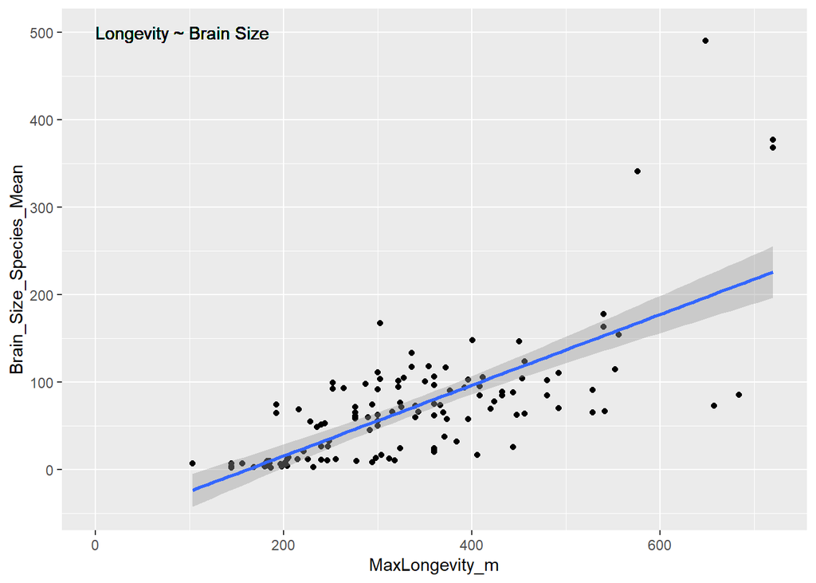

```r
#Fitting the regression model
#First Model
m<- lm(MaxLongevity_m ~ Brain_Size_Species_Mean, data= d)


#Graphing
g <- ggplot(data = d, aes(x = MaxLongevity_m, y = Brain_Size_Species_Mean ))
g <- g + geom_point()
g <- g + geom_smooth(method = "lm", formula = y ~ x)
g <- g + geom_text(aes(x = 0, y = 500), hjust = 0,label =  "Longevity ~ Brain Size" )
g
```

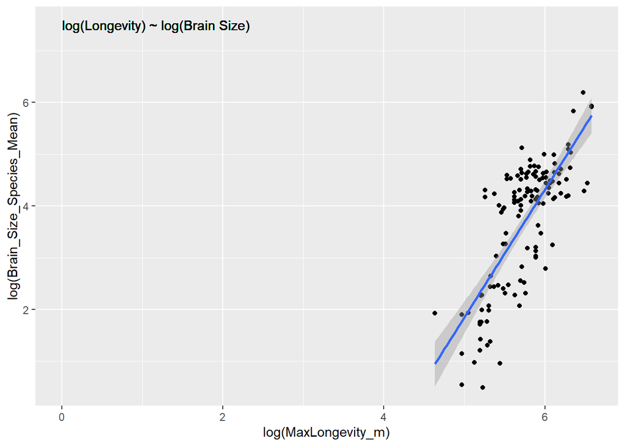

```r
#log MOdel
n<- lm(log(MaxLongevity_m) ~ log(Brain_Size_Species_Mean), data= d)
h <- ggplot(data = d, aes(x = log(MaxLongevity_m), y = log(Brain_Size_Species_Mean) ))
h <- h + geom_point()
h <- h + geom_smooth(method = "lm", formula = y ~ x)
h <- h + geom_text(aes(x = 0, y = 7.5), hjust = 0,label =  "log(Longevity) ~ log(Brain Size)" )
h
```

```r
#want to organize the graphs side by side
par(mfrow = c(1,2))
```

Identify and interpret the point estimate of the slope (β1), as well as the outcome of the test associated with the hypotheses H0: β1 = 0; HA: β1 ≠ 0. Also, find a 90 percent CI for the slope (β1) parameter.

```
##
## Call:
## lm(formula = MaxLongevity_m ~ Brain_Size_Species_Mean, data = d)
##
## Coefficients:
##             (Intercept)  Brain_Size_Species_Mean
##                 248.952                    1.218
```

```
##                               Est         SE       t            p
## (Intercept)             248.95227 11.1111143 22.4057 8.910319e-46
## Brain_Size_Species_Mean   1.21799  0.1100879 11.0638 2.685909e-20
```

Looking at the t-test values, the outcome would be to reject H0.

```
##                                5 %      95 %
## (Intercept)             230.540738 267.36379
## Brain_Size_Species_Mean   1.035571   1.40041
```

#These are for the log funcion

```
##
## Call:
## lm(formula = log(MaxLongevity_m) ~ log(Brain_Size_Species_Mean),
##     data = d)
##
## Coefficients:
##                  (Intercept)  log(Brain_Size_Species_Mean)
##                       4.8790                        0.2341
```

```
##                                    Est         SE        t             p
## (Intercept)                  4.8789509 0.06907361 70.63408 3.321721e-103
## log(Brain_Size_Species_Mean) 0.2341496 0.01780887 13.14792  2.165214e-25
```

Looking at the t-test values, the outcome would be to reject H0.

```
##                                    5 %      95 %
## (Intercept)                  4.7644934 4.9934084
## log(Brain_Size_Species_Mean) 0.2046396 0.2636595
```

Using your model, add lines for the 90 percent confidence and prediction interval bands on the plot and add a legend to differentiate between the lines.

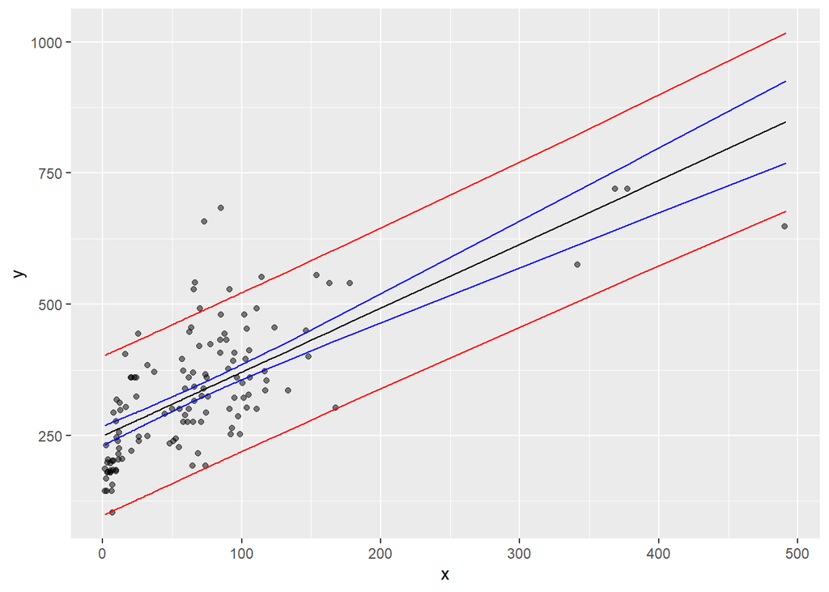

```r
#first equation
#this creates the predictions for the CI Intervals
ci <- predict(m, newdata = data.frame(Brain_Size_Species_Mean = d$Brain_Size_Species_Mean), interval = "confidence", level = 0.90)  # for a vector of values
h_hat <- predict(m, newdata = data.frame(Brain_Size_Species_Mean = d$Brain_Size_Species_Mean))
#this puts it into a df and organizes it
df <- data.frame(cbind(d$Brain_Size_Species_Mean, d$MaxLongevity_m, h_hat))
names(df) <- c("x", "y", "yhat")
df <- cbind(df, ci)
names(df) <- c("x", "y", "yhat", "CIfit", "CIlwr", "CIupr")
#this creates the predictions for the PI INtervals
pi <- predict(m, newdata = data.frame(Brain_Size_Species_Mean = d$Brain_Size_Species_Mean), interval = "prediction",
    level = 0.90)  # for a vector of values
pf <- cbind(df, pi)
names(pf) <- c("x", "y", "yhat", "CIfit", "CIlwr", "CIupr", "PIfit", "PIlwr",
    "PIupr")
#This starts the plotting
g <- ggplot(data = df, aes(x = x, y = y))
g <- g + geom_point(alpha = 1/2)
g <- g + geom_line(aes(x = x, y = CIfit), colour = "black")
g <- g + geom_line(aes(x = x, y = CIlwr), colour = "blue")
g <- g + geom_line(aes(x = x, y = CIupr), colour = "blue")
g <- g + geom_line(data = pf, aes(x = x, y = PIlwr), colour = "red")
g <- g + geom_line(data = pf, aes(x = x, y = PIupr), colour = "red")
#g <- g + scale_colour_manual("", values = c("black"="black", "Confidence Interval"="blue", "Prediction Interval"="red"))
g <- g + scale_colour_manual(name="Intervals", values = c("Confidence" = "blue", "Prediction" = "red") )

#g <- g + scale_fill_discrete(name="Interval",
#                         breaks=c("blue", "red"),
#                         labels=c("Confidence Interval", "Prediction Interval"))

#This line doesnt work-YET
#g <- g + theme (
  legend.position = c(0.95, 0.95)
  legend.justification = "right"
g
```

# cannot make the legend show up #FA: From line 286 to 297 I used the next code, I am not sure if it is the correct way to make the legend the show up, and I think it works on the log equation too. #FA: g <- g + geom_line(aes(x = x, y = CIfit, colour = “black”)) #FA: g <- g + geom_line(aes(x = x, y = CIlwr, colour = “Confidence Interval”)) #FA: g <- g + geom_line(aes(x = x, y = CIupr, colour = “Confidence Interval”)) #FA: g <- g + geom_line(data = pf, aes(x = x, y = PIlwr, colour = “Prediction Interval”)) #FA: g <- g + geom_line(data = pf, aes(x = x, y = PIupr, colour = “Prediction Interval”)) #FA: g <- g + scale_colour_manual("“, values = c(”black“=”black“,”Confidence Interval“=”blue“,”Prediction Interval“=”red“)) #FA: g <- g + theme ( #FA: legend.position = c(0.95, 0.2), #FA: legend.justification = c(”right"))

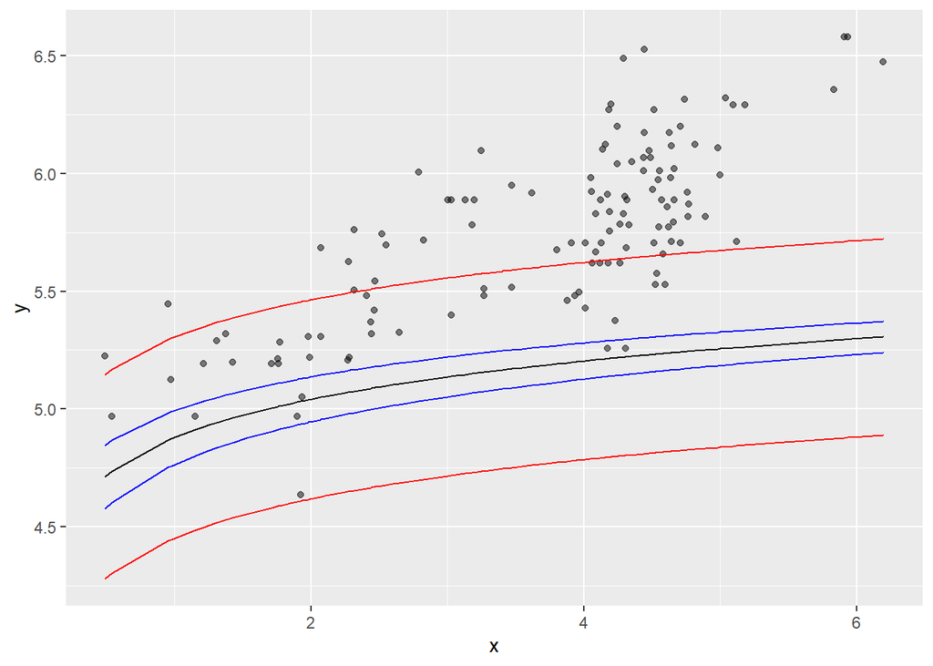

```r
#log equation
cil <- predict(n, newdata = data.frame(Brain_Size_Species_Mean = log(d$Brain_Size_Species_Mean)), interval = "confidence", level = 0.90)

hl_hat <- predict(n, newdata = data.frame(Brain_Size_Species_Mean = log(d$Brain_Size_Species_Mean)))

dfl <- data.frame(cbind(log(d$Brain_Size_Species_Mean), log(d$MaxLongevity_m), hl_hat))
names(dfl) <- c("x", "y", "yhat")

dfl <- cbind(dfl, cil)

names(dfl) <- c("x", "y", "yhat", "CIfit", "CIlwr", "CIupr")
#this creates the predictions for the PI INtervals
pil <- predict(n, newdata = data.frame(Brain_Size_Species_Mean = log(d$Brain_Size_Species_Mean)), interval = "prediction",
    level = 0.90)
pfl <- cbind(dfl, pil)

names(pfl) <- c("x", "y", "yhat", "CIfit", "CIlwr", "CIupr", "PIfit", "PIlwr",
    "PIupr")
#this is the actual graphing
g <- ggplot(data = dfl, aes(x = x, y = y))
g <- g + geom_point(alpha = 1/2)
g <- g + geom_line(aes(x = x, y = CIfit), colour = "black")
g <- g + geom_line(aes(x = x, y = CIlwr), colour = "blue")
g <- g + geom_line(aes(x = x, y = CIupr), colour = "blue")
g <- g + geom_line(data = pfl, aes(x = x, y = PIlwr), colour = "red")
g <- g + geom_line(data = pfl, aes(x = x, y = PIupr), colour = "red")
g <- g + scale_colour_manual("",
                      breaks = c("Confidence Interval", "Prediction Interval"),
                      values = c("blue", "red"))
g
```

#these lines are wrong, they dont look like they fit #the legend continues to not work

Produce a point estimate and associated 90 percent PI for the longevity of a species whose brain weight is 800 gm. Do you trust the model to predict observations accurately for this value of the explanatory variable? Why or why not?

```
##        fit      lwr      upr
## 1 1223.345 1089.461 1357.228
```

I dont trust this model to predict accuratly, as the CI interval are very large, since the data doesnt have much information that far out. The CI is more than 100 months above or below the point estimate, which is 11 years.

For the log function

```
##       fit      lwr      upr
## 1 5.32379 5.259948 5.387632
```

I wouldnt trust this becasue I cant understand it. If you log transform them back…

```r
exp(5.32379)
```

```
## [1] 205.16
```

```r
exp(5.259948)
```

```
## [1] 192.4715
```

```r
exp(5.387632)
```

```
## [1] 218.6849
```

Looking at your two models, which do you think is better? Why? I prefer the first model, as it is easier to interpret. It may be becasue my math is wrong, but the CIs for the log function seem large in the graphs.

> 5 Challenges

1. I had serious issuse with the large function, I had trouble with the statements for if n2 or p2 were null. I think it works now but I am unsure.  
2. I am still having trouble getting the legend onto the graphs for the CI and PIs  
3. My graphed intervals do not match the data at all for the log function and Im not sure where my problem is.  
4. I kept running into issues when trying to create the dataframe with all the CI and PI calculations. I had an issue with the various names for objects that I have fixed  
5. Im still a bit confused about the function and Im not sure if it calculates stats properly.